# 04-exercises-mapping

Charlie Reinahrdt

# Exercises 4: Mapping Supplementary Exercises

Consider again the Happy Planet Index data that we worked with in Section 5.2 It may be helpful to reread the description of the data set.

```r
library(tidyverse)
library(maps)
library(here)
library(knitr)
hpi_df <- read_csv(here("data/hpi-tidy.csv"))
world_map <- ggplot2::map_data("world")

df_full <- left_join(world_map, hpi_df, by = c("region" = "Country"))
```

### Exericse 1.

Make a map of a variable of your choosing. In coord_map(), use projection = “mercator”, which is also the default (we will see in a later exercise that this probably is not the best choice).

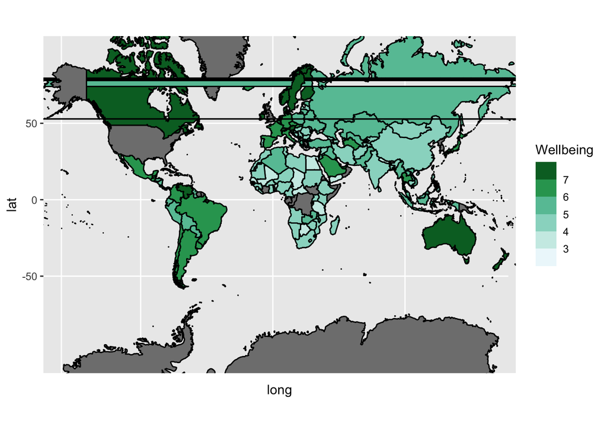

```r
ggplot(data = df_full, mapping = aes(x = long, y = lat, group = group)) +
  geom_polygon(color = "black", aes(fill = Wellbeing)) +
  coord_map(projection = "mercator") +
  scale_fill_fermenter(type = "seq", direction = 1, palette = 2)
```

Hint: in ggplot2’s map_data() function, there is a built in map of the “world”.

Hint: You can read more about projections in Section 17.3.2 of Modern Data Science with R

Exercise 2. You may notice that the United States does not get coloured in your map. Examine this issue further and fix the map so that the United States is coloured.

```r
# investigation
df_full %>% filter(region == "USA") %>% head %>% kable()
```

| long | lat | group | order | region | subregion | HPIRank | LifeExpectancy | Wellbeing | HappyLifeYears | Footprint | HappyPlanetIndex | Population | GDPcapita | GovernanceRank | Region |
| --- | --- | --- | --- | --- | --- | --- | --- | --- | --- | --- | --- | --- | --- | --- | --- |
| -155.5813 | 19.01201 | 1443 | 91664 | USA | Hawaii | NA | NA | NA | NA | NA | NA | NA | NA | NA | NA |
| -155.6256 | 18.96392 | 1443 | 91665 | USA | Hawaii | NA | NA | NA | NA | NA | NA | NA | NA | NA | NA |
| -155.6808 | 18.96768 | 1443 | 91666 | USA | Hawaii | NA | NA | NA | NA | NA | NA | NA | NA | NA | NA |
| -155.8813 | 19.07051 | 1443 | 91667 | USA | Hawaii | NA | NA | NA | NA | NA | NA | NA | NA | NA | NA |
| -155.9056 | 19.12583 | 1443 | 91668 | USA | Hawaii | NA | NA | NA | NA | NA | NA | NA | NA | NA | NA |
| -155.8907 | 19.38252 | 1443 | 91669 | USA | Hawaii | NA | NA | NA | NA | NA | NA | NA | NA | NA | NA |

```r
hpi_df %>% summarise(Country) %>% distinct() %>% filter(str_starts(Country, "U")) %>% head() %>% kable()
```

| Country |
| --- |
| Uganda |
| Ukraine |
| United Arab Emirates |
| United Kingdom |
| United States of America |
| Uruguay |

```r
# cleaning
df_full_US <-
  hpi_df %>% mutate(Country = str_replace(Country, "United States of America", "USA")) %>%
  left_join(world_map, ., by = c("region" = "Country"))

df_full_US %>% filter(region == "USA") %>% head() %>% kable()
```

| long | lat | group | order | region | subregion | HPIRank | LifeExpectancy | Wellbeing | HappyLifeYears | Footprint | HappyPlanetIndex | Population | GDPcapita | GovernanceRank | Region |
| --- | --- | --- | --- | --- | --- | --- | --- | --- | --- | --- | --- | --- | --- | --- | --- |
| -155.5813 | 19.01201 | 1443 | 91664 | USA | Hawaii | 105 | 78.5 | 7.163616 | 61.28521 | 7.189133 | 37.34011 | 309349000 | 47153.01 | 21 | Western World |
| -155.6256 | 18.96392 | 1443 | 91665 | USA | Hawaii | 105 | 78.5 | 7.163616 | 61.28521 | 7.189133 | 37.34011 | 309349000 | 47153.01 | 21 | Western World |
| -155.6808 | 18.96768 | 1443 | 91666 | USA | Hawaii | 105 | 78.5 | 7.163616 | 61.28521 | 7.189133 | 37.34011 | 309349000 | 47153.01 | 21 | Western World |
| -155.8813 | 19.07051 | 1443 | 91667 | USA | Hawaii | 105 | 78.5 | 7.163616 | 61.28521 | 7.189133 | 37.34011 | 309349000 | 47153.01 | 21 | Western World |
| -155.9056 | 19.12583 | 1443 | 91668 | USA | Hawaii | 105 | 78.5 | 7.163616 | 61.28521 | 7.189133 | 37.34011 | 309349000 | 47153.01 | 21 | Western World |
| -155.8907 | 19.38252 | 1443 | 91669 | USA | Hawaii | 105 | 78.5 | 7.163616 | 61.28521 | 7.189133 | 37.34011 | 309349000 | 47153.01 | 21 | Western World |

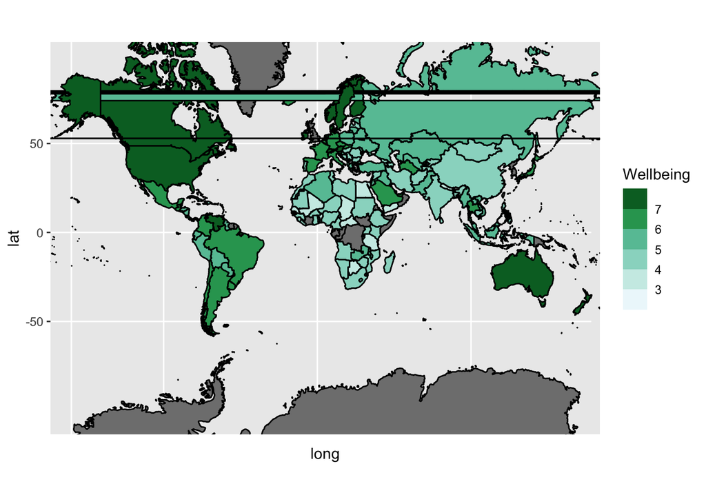

```r
# mapping
ggplot(data = df_full_US, mapping = aes(x = long, y = lat, group = group)) +
  geom_polygon(color = "black", aes(fill = Wellbeing)) +
  coord_map(projection = "mercator") +
  scale_fill_fermenter(type = "seq", direction = 1, palette = 2)
```

Exercise 3. You may have noticed that there are two horizontal stripes across your map. This is an issue that drove me nuts! Check out this submitted issue on ggplot2’s GitHub page for the reason for the error as well as a fix. Use it to fix your plot.

https://github.com/tidyverse/ggplot2/issues/1104

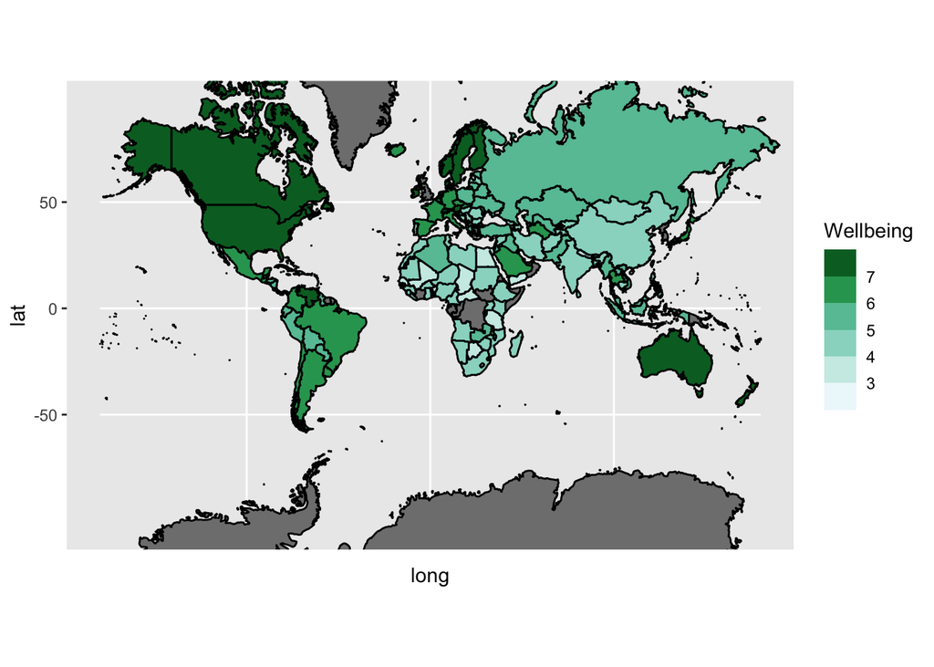

```r
ggplot(data = df_full_US, mapping = aes(x = long, y = lat, group = group)) +
  geom_polygon(color = "black", aes(fill = Wellbeing)) +
  coord_map(projection = "mercator", xlim = c(-180, 180)) +
  scale_fill_fermenter(type = "seq", direction = 1, palette = 2)
```

Exercise 4. Read about Mercator projections in this blog post. What does this source say about the sizes of Greenland vs. Africa in a Mercator projection.

https://futuremaps.com/blogs/news/top-10-world-map-projections

This blog post says that Greenland is way too big in the Mercator projections! According to the blog post, Greenland should be able to fit into Africa 14 times, whereas on this map Greenland and Africa appear to be roughly similar size.

Exercise 5. Examine all of the different options for map projection with ?mapproject. Then, change the projection to “globular”. Change the projection again to “gilbert”. How does the relative size of Greenland to Africa change in the projections?

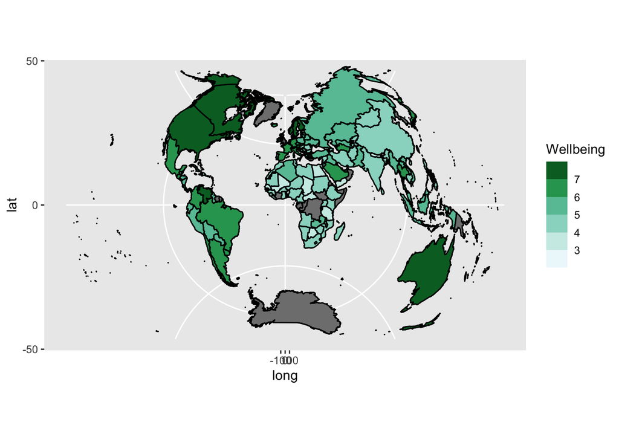

```r
ggplot(data = df_full_US, mapping = aes(x = long, y = lat, group = group)) +
  geom_polygon(color = "black", aes(fill = Wellbeing)) +
  coord_map(projection = "globular", xlim = c(-180, 180)) +
  scale_fill_fermenter(type = "seq", direction = 1, palette = 2)
```

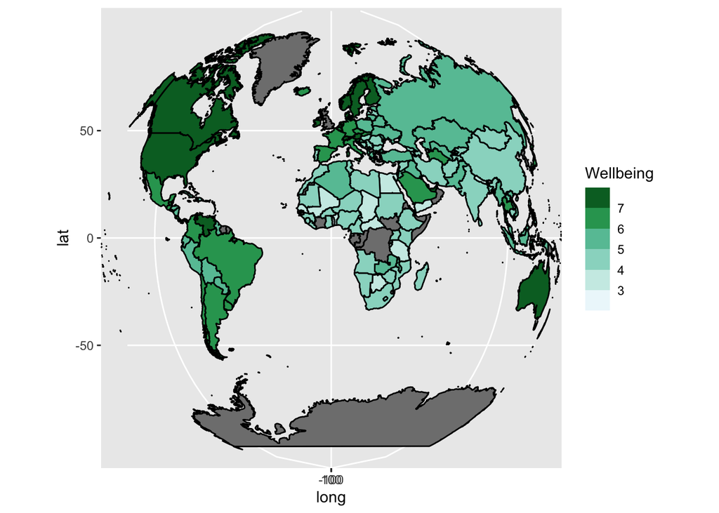

```r
ggplot(data = df_full_US, mapping = aes(x = long, y = lat, group = group)) +
  geom_polygon(color = "black", aes(fill = Wellbeing)) +
  coord_map(projection = "gilbert", xlim = c(-180, 180)) +
  scale_fill_fermenter(type = "seq", direction = 1, palette = 2)
```

The globular projection looks like it nails the size proportions of Greenland and Africa, but the map loses some of the familiarity of the more common Mercator projection, which may make it harder for viewers to interpret the graphs.

The Gilbert projection seems like a compromise between the Mercator and Globular projections. Gilbert has more accurate size proportions than Mercator, but not quite as accurate as Globular. However, Gilbert is much more positionally similar to Mercator (compared to Globular), which will likely aid in viewers interpreting the graphic.

You can read more about projections in R at this site. There’s definitely a lot going on, and you should always consider what map projection you are using when mapping data, especially if that data is on a global scale!

https://rud.is/b/2015/07/24/a-path-towards-easier-map-projection-machinations-with-ggplot2/